# beanz: Bayesian Analysis of Heterogeneous Treatment Effect

Chenguang Wang and Ravi Varadhan

2018-06-13

# Introduction

In patient-centered outcomes research, it is vital to assess the heterogeneity of treatment effects (HTE) when making health care decisions for an individual patient or a group of patients. Nevertheless, it remains challenging to evaluate HTE based on information collected from clinical studies that are often designed and conducted to evaluate the efficacy of a treatment for the overall population. The Bayesian framework offers a principled and flexible approach to estimate and compare treatment effects across subgroups of patients defined by their characteristics.

*R* package **beanz** provides functions to facilitate the conduct of Bayesian analysis of HTE and a web-based graphical user interface for users to conduct such Bayesian analysis in an interactive and user-friendly manner.

# Data accepted by **beanz**

There are two types of data structures that **beanz** recognizes:

- Summary treatment effect data: Each row should represent a subgroup with covariates that define the subgroup, estimated treatment effect in the subgroup and variance for the estimation.
- Patient level raw data: Each row should represent a patient with covariates that define the subgroup in which the patient belongs to, treatment indicator and outcome. The outcome can be binary, continuous, or time to event.

The **beanz** package provides dataset *solvd.sub* from the *SOLVD* trial as an example *Patient level raw data* dataset.

# Estimate subgroup effect

If *Patient level raw data* is provided, the package provides function *bzGetSubgrpRaw* for estimating subgroup effect for each subgroup. The return value from *bzGetSubgrpRaw* is a data frame with the format of *Summary treatment effect data*.

The example is as follows:

```r
var.cov    <- c("lvef", "sodium", "any.vasodilator.use");
var.resp   <- "y";
var.trt    <- "trt";
var.censor <- "censor";
resptype   <- "survival";

subgrp.effect <- bzGetSubgrpRaw(solvd.sub,
                                  var.resp   = var.resp,
                                  var.trt    = var.trt,
                                  var.cov    = var.cov,
                                  var.censor = var.censor,
                                  resptype   = resptype);
print(subgrp.effect);
```

```
##   Subgroup lvef sodium any.vasodilator.use    Estimate   Variance   N
## 1        1    0      0                   0 -0.37783038 0.01212786 562
## 2        2    0      0                   1 -0.34655336 0.01004499 695
## 3        3    0      1                   0 -0.79235451 0.03939983 237
## 4        4    0      1                   1 -0.39334304 0.02969421 250
## 5        5    1      0                   0  0.06776454 0.04629163 223
## 6        6    1      0                   1 -0.23655764 0.02400353 341
## 7        7    1      1                   0  0.15435495 0.10365396 104
## 8        8    1      1                   1  0.05947290 0.07761840 123
```

# Bayesian HTE models

The function *bzCallStan* calls *rstan::sampling* to draw samples for different Bayesian models. The following models are available in the current version of **beanz**:

- *nse*: No subgroup effect model
- *fs*: Full stratification model
- *sr*: Simple regression model
- *bs*: Basic shrinkage model
- *srs*: Simple regression with shrinkage model
- *ds*: Dixon-Simon model
- *eds*: Extended Dixon-Simon model.

The following examples show how *No subgroup effect model* (*nse),* Simple regression model* (*sr*) and *Basic shrinkage model* (*bs*) are called:

```r
var.estvar <- c("Estimate", "Variance");

rst.nse <- bzCallStan("nse", dat.sub=subgrp.effect,
                     var.estvar = var.estvar, var.cov = var.cov,
                     par.pri = c(B=1000),
                     chains=4, iter=4000,
                     warmup=2000, seed=1000, cores=1);
```

[output not shown]

[output cut: 40 more lines]

[output not shown]

```r
rst.sr  <- bzCallStan("sr", dat.sub=subgrp.effect,
                     var.estvar = var.estvar, var.cov = var.cov,
                     par.pri = c(B=1000, C=1000),
                     chains=4, iter=4000,
                     warmup=2000,  seed=1000, cores=1);
```

[output not shown]

[output cut: 40 more lines]

[output not shown]

```r
rst.bs  <- bzCallStan("bs", dat.sub=subgrp.effect,
                     var.estvar = var.estvar, var.cov = var.cov,
                     par.pri = c(B=1000, D=1),
                     chains=4, iter=4000, warmup=2000,  seed=1000, cores=1);
```

[output not shown]

[output cut: 40 more lines]

[output not shown]

# Results presentation

## Posterior subgroup treatment effect summary

Posterior subgroup treatment effect can be summarized and presented by functions *bzSummary*, *bzPlot* and *bzForest*. These functions allows to include a subgroup from another model (i.e. No subgroup effect model) as a reference in the results.

### Simple regression model

```r
sel.grps <- c(1,4,5);
tbl.sub <- bzSummary(rst.sr, ref.stan.rst=rst.nse, ref.sel.grps=1);
print(tbl.sub);
```

```
##                Subgroup   Mean    SD   Q025    Q25 Median    Q75   Q975
## 1            Subgroup 1 -0.401 0.095 -0.586 -0.464 -0.402 -0.336 -0.215
## 2            Subgroup 2 -0.381 0.088 -0.556  -0.44  -0.38 -0.322 -0.208
## 3            Subgroup 3 -0.485  0.13 -0.739 -0.575 -0.485 -0.396 -0.238
## 4            Subgroup 4 -0.465 0.124 -0.709  -0.55 -0.466 -0.382 -0.222
## 5            Subgroup 5 -0.062 0.135 -0.327 -0.151 -0.063   0.03  0.199
## 6            Subgroup 6 -0.042 0.119 -0.277 -0.124 -0.042  0.036  0.193
## 7            Subgroup 7 -0.147 0.161 -0.467 -0.256 -0.145 -0.037  0.166
## 8            Subgroup 8 -0.127 0.148 -0.408 -0.229 -0.128 -0.029  0.163
## 9 No subgroup effect(1) -0.322 0.057 -0.432 -0.361 -0.322 -0.284  -0.21
##   ProbLT0
## 1       1
## 2       1
## 3       1
## 4       1
## 5   0.678
## 6   0.638
## 7   0.821
## 8   0.808
## 9       1
```

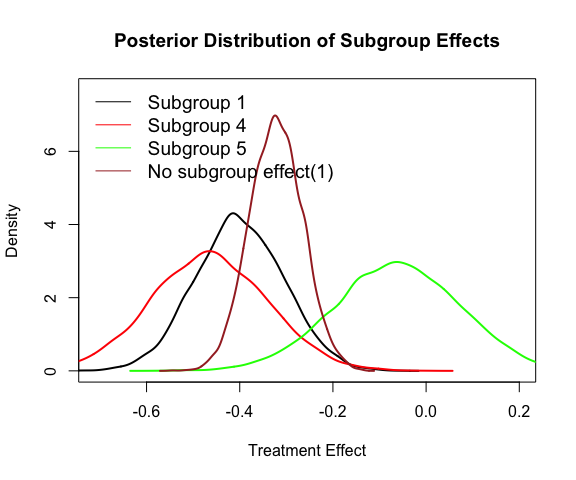

```r
bzPlot(rst.sr, sel.grps = sel.grps, ref.stan.rst=rst.nse, ref.sel.grps=1);
```

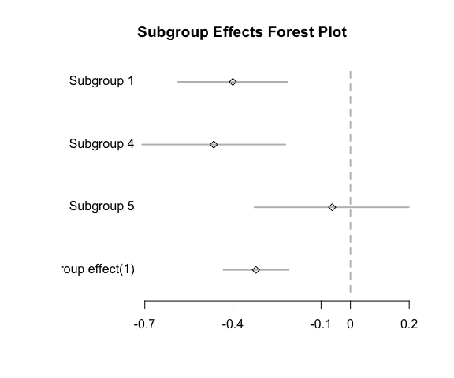

```r
bzForest(rst.sr, sel.grps = sel.grps, ref.stan.rst=rst.nse, ref.sel.grps=1);
```

### Basic shrinkage model

```r
tbl.sub <- bzSummary(rst.bs, ref.stan.rst=rst.nse, ref.sel.grps=1);
print(tbl.sub);
```

```
##                Subgroup   Mean    SD   Q025    Q25 Median    Q75   Q975
## 1            Subgroup 1 -0.352 0.096 -0.547 -0.413 -0.349 -0.287 -0.167
## 2            Subgroup 2 -0.333 0.086 -0.505  -0.39 -0.333 -0.276 -0.164
## 3            Subgroup 3 -0.518 0.185 -0.923 -0.641 -0.494 -0.375 -0.233
## 4            Subgroup 4 -0.345  0.13 -0.614 -0.423 -0.341 -0.266 -0.087
## 5            Subgroup 5 -0.141 0.183 -0.431 -0.281 -0.166 -0.022  0.262
## 6            Subgroup 6 -0.267 0.122 -0.492 -0.348 -0.275  -0.19 -0.006
## 7            Subgroup 7 -0.167 0.215 -0.505 -0.318 -0.207 -0.043  0.325
## 8            Subgroup 8  -0.18 0.191 -0.489 -0.315 -0.209 -0.067  0.259
## 9 No subgroup effect(1) -0.322 0.057 -0.432 -0.361 -0.322 -0.284  -0.21
##   ProbLT0
## 1       1
## 2       1
## 3       1
## 4   0.994
## 5    0.78
## 6   0.978
## 7   0.793
## 8   0.832
## 9       1
```

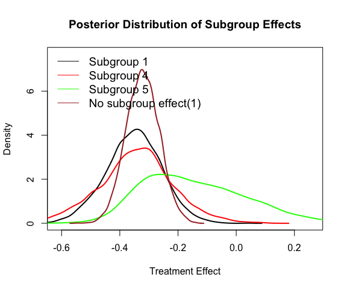

```r
bzPlot(rst.bs, sel.grps = sel.grps, ref.stan.rst=rst.nse, ref.sel.grps=1);
```

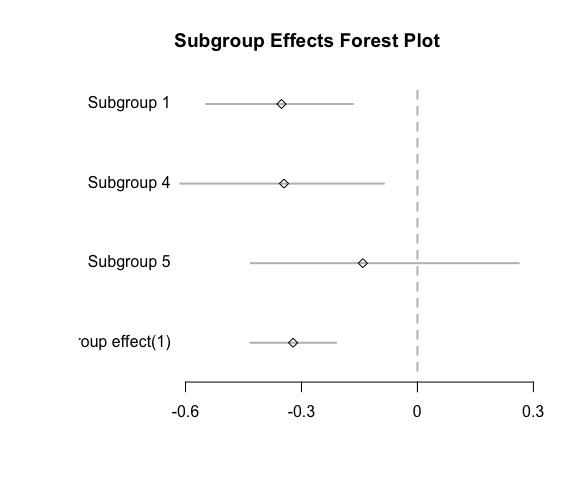

```r
bzForest(rst.bs, sel.grps = sel.grps, ref.stan.rst=rst.nse, ref.sel.grps=1);
```

## Posterior subgroup treatment effect comparison

Posterior subgroup treatment effect can be compared between subgroups by functions *bzSummaryComp*, *bzPlotComp* and *bzForestComp*.

### Simple regression model

```r
tbl.sub <- bzSummaryComp(rst.sr, sel.grps=sel.grps);
print(tbl.sub);
```

```
##     Comparison   Mean    SD   Q025    Q25 Median   Q75  Q975 ProbLT0
## 1 Subgroup 4-1 -0.065 0.158 -0.369 -0.172 -0.066  0.04 0.248   0.665
## 2 Subgroup 5-1  0.337 0.164  0.012  0.229  0.335 0.445 0.663   0.021
## 3 Subgroup 5-4  0.406 0.183  0.044  0.284  0.406  0.53 0.758   0.013
```

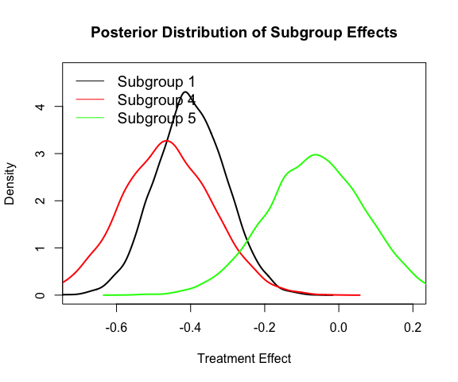

```r
bzPlot(rst.sr, sel.grps = sel.grps);
```

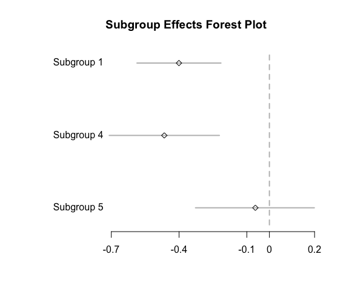

```r
bzForest(rst.sr, sel.grps = sel.grps);
```

### Basic shrinkage model

```r
tbl.sub <- bzSummaryComp(rst.bs, sel.grps=sel.grps);
print(tbl.sub);
```

```
##     Comparison  Mean    SD   Q025    Q25 Median   Q75  Q975 ProbLT0
## 1 Subgroup 4-1 0.005 0.163 -0.321 -0.101  0.007 0.112 0.325    0.48
## 2 Subgroup 5-1 0.209 0.208 -0.152  0.061  0.192 0.345 0.653   0.152
## 3 Subgroup 5-4 0.206 0.223 -0.195  0.051   0.19 0.346 0.683   0.177
```

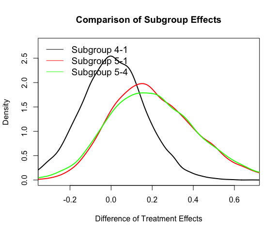

```r
bzPlotComp(rst.bs, sel.grps = sel.grps);
```

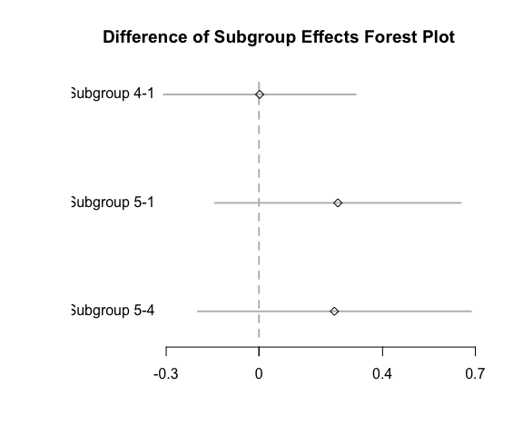

```r
bzForestComp(rst.bs, sel.grps = sel.grps);
```

## Overall summary

**beanz** provides function *bzRptTbl* to generate the summary posterior subgroup treatment effect table from the model selected by DIC (i.e. the model with the smallest DIC):

```r
lst.rst     <- list(nse=rst.nse, sr=rst.sr, bs=rst.bs);
tbl.summary <- bzRptTbl(lst.rst, dat.sub = subgrp.effect, var.cov = var.cov);
print(tbl.summary);
```

```
##                         Model Subgroup lvef sodium any.vasodilator.use
## Subgroup 1 No subgroup effect        1    0      0                   0
## Subgroup 2 No subgroup effect        2    0      0                   1
## Subgroup 3 No subgroup effect        3    0      1                   0
## Subgroup 4 No subgroup effect        4    0      1                   1
## Subgroup 5 No subgroup effect        5    1      0                   0
## Subgroup 6 No subgroup effect        6    1      0                   1
## Subgroup 7 No subgroup effect        7    1      1                   0
## Subgroup 8 No subgroup effect        8    1      1                   1
##              Mean    SD Prob < 0
## Subgroup 1 -0.322 0.057        1
## Subgroup 2 -0.322 0.057        1
## Subgroup 3 -0.322 0.057        1
## Subgroup 4 -0.322 0.057        1
## Subgroup 5 -0.322 0.057        1
## Subgroup 6 -0.322 0.057        1
## Subgroup 7 -0.322 0.057        1
## Subgroup 8 -0.322 0.057        1
```

# Predictive distribution

Function *bzPredSubgrp* generates the predictive distribution of the subgrooup treatment effects.

```r
pred.dist <- bzPredSubgrp(rst.sr,
                                  dat.sub=subgrp.effect,
                                  var.estvar = var.estvar);
head(pred.dist);
```

```
##            [,1]       [,2]       [,3]       [,4]        [,5]         [,6]
## [1,] -0.2139431 -0.1950989 -0.7298465 -0.4751291 -0.05987575  0.005320552
## [2,] -0.3214511 -0.3645186 -0.6025874 -0.6090846 -0.06453451  0.138157454
## [3,] -0.4771825 -0.2499599 -0.5938340 -0.6897693  0.25255032 -0.393141590
## [4,] -0.1686947 -0.2174068 -0.3967592 -0.1578458  0.04432626  0.129928079
## [5,] -0.5387784 -0.5184029 -0.5521909 -0.6691116  0.22789620 -0.014631222
## [6,] -0.1453486 -0.4018996 -0.4067673 -0.5256097 -0.19352722  0.044520821
##               [,7]        [,8]
## [1,]  0.0547029104 -0.17041925
## [2,] -0.7211423472 -0.20721475
## [3,] -0.0510737068 -0.19883551
## [4,]  0.1363043133 -0.16918687
## [5,] -0.0009383121  0.30016887
## [6,] -0.0791177689 -0.04636402
```

# Graphical User Interface

With package *shiny* installed, *beaz* provides a web-based graphical user interface (GUI) for conducting the HTE analysis in an user-friendly interactive manner. The GUI can be started by

```r
bzShiny();
```

# Toolbox

Package **beanz** provides function *bzGailSimon* that implements the Gail-Simon test for qualitative interactions:

```r
gs.pval <- bzGailSimon(subgrp.effect$Estimate,
                       sqrt(subgrp.effect$Variance));
print(gs.pval);
```

```
## [1] 0.9191656
```

The result show that there is no significant qualitative interactions according to the Gail-Simon test.